# MODELOS LINEARES GENERALIZADOS (EST082)

RESOLUÇÃO - LISTA 1

Autor

Jaqueline Lamas da Silva

# Parte A: **Paula (2013), Cap. 1**

**Análise de resíduo, validação do modelo e análise de diagnóstico.**

## 19

**Variáveis:**

- 1. estado (nome do estado);
- 2. pop(população estimada em julho de 1975);
- 3. percap (renda percapita em 1974 em USD);
- 4. analf (proporção de analfabetos em 1970),
- 22. expvida (expectativa de vida em anos 1969-70);
- 6. crime (taxa de criminalidade por 100000 habitantes 1976);
- 7. estud (porcentagem de estudantes que concluem o segundo grau 1970);
- 8. ndias (número de dias do ano com temperatura abaixo de zero grau Celsus na cidade mais importante do estado);
- 9. area (área do estado em milhas quadradas).

**Código**

```r
reg3 <-read.table("./dados/lista1/reg3.txt", quote="\"")
# Nomear as colunas do data frame
colnames(reg3) <- c("estado",    # (i) Nome do estado
                    "pop",       # (ii) População estimada em julho de 1975
                    "percap",    # (iii) Renda per capita em 1974 em USD
                    "analf",     # (iv) Proporção de analfabetos em 1970
                    "expvida",   # (v) Expectativa de vida em anos 1969-70
                    "crime",     # (vi) Taxa de criminalidade por 100000 habitantes em 1976
                    "estud",     # (vii) Porcentagem de estudantes que concluem o segundo grau em 1970
                    "ndias",     # (viii) Número de dias do ano com temperatura abaixo de zero grau Celsius
                    "area")      # (ix) Área do estado em milhas quadradas
```

Queremos explicar e variável **expvida** usando um modelo de regressão normal linear dadas as variáveis explicativas percap, analf, crime, estud, ndias e dens, em que dens=pop/area.

### Análise exploratória

**Código**

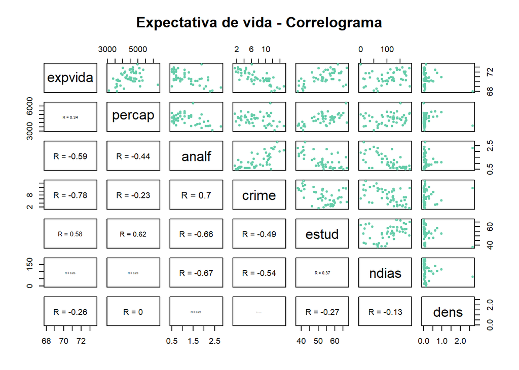

```r
reg3<- reg3 |>
  mutate(dens=pop/area)
attach(reg3)
painel.pearson <- function(x, y, ...) {
    horizontal <- (par("usr")[1] + par("usr")[2]) / 2;
    vertical <- (par("usr")[3] + par("usr")[4]) / 2;
    text(horizontal, vertical, format(abs(cor(x,y)), digits=2))
}

painel.prop <- function(x, y, ...){
  usr <- par("usr"); on.exit(par(usr))
  par(usr = c(0, 1, 0, 1))
  r <- round(cor(x, y), digits = 2)
  txt <- paste0("R = ", r)
  cex.cor <- 0.8/strwidth(txt)
  text(0.5, 0.5, txt, cex = cex.cor * r)
}

pairs(reg3[,c(5,3,4,6,7,8,10)], main = "Expectativa de vida - Correlograma", pch = 20, col="aquamarine3",
    lower.panel = painel.prop)
```

No gráfico acima temos o diagrama de dispersão de todas as possíveis variáveis explicativas com a resposta. Pelo gráfico de dispersão, as variáveis parecem estar relacionadas de forma linear com a expectativa de vida, isso pode ser verificado também pela correlação entre elas. Além disso, temos que algumas variáveis explicativas possuem relacionamento entre si, isso pode gerar problemas de multicolinearidade.

**Código**

```r
ajuste0<-lm(expvida~percap+analf+crime+estud+ndias+dens, data = reg3)
```

### Seleção de variáveis

Vamos utilizar o critério AIC para selecionar as variáveis.

**Código**

```r
ajuste<-stepAIC(ajuste0,direction="backward")
```

```
Start:  AIC=-24.38
expvida ~ percap + analf + crime + estud + ndias + dens

         Df Sum of Sq    RSS     AIC
- analf   1    0.0138 23.221 -26.348
- percap  1    0.5006 23.708 -25.311
<none>                23.207 -24.378
- estud   1    1.1626 24.370 -23.933
- dens    1    1.8507 25.058 -22.541
- ndias   1    3.9515 27.159 -18.516
- crime   1   26.0954 49.303  11.298

Step:  AIC=-26.35
expvida ~ percap + crime + estud + ndias + dens

         Df Sum of Sq    RSS     AIC
- percap  1     0.544 23.766 -27.189
<none>                23.221 -26.348
- estud   1     1.376 24.597 -25.469
- dens    1     1.968 25.189 -24.280
- ndias   1     4.872 28.093 -18.826
- crime   1    33.886 57.107  16.645

Step:  AIC=-27.19
expvida ~ crime + estud + ndias + dens

        Df Sum of Sq    RSS     AIC
<none>               23.766 -27.189
- dens   1     1.606 25.372 -25.920
- estud  1     4.294 28.060 -20.884
- ndias  1     4.682 28.447 -20.199
- crime  1    33.342 57.108  14.646
```

As variáveis selecionadas são: crime, estud, ndias, dens.

**Código**

```r
modelo<-lm(expvida ~ crime + estud + ndias + dens, data=reg3)
summary(modelo)
```

```
Call:
lm(formula = expvida ~ crime + estud + ndias + dens, data = reg3)

Residuals:
     Min       1Q   Median       3Q      Max
-1.56186 -0.53406  0.06514  0.54981  1.23075

Coefficients:
             Estimate Std. Error t value Pr(>|t|)
(Intercept) 71.501488   0.998428  71.614  < 2e-16 ***
crime       -0.285873   0.035979  -7.946 4.14e-10 ***
estud        0.043649   0.015307   2.852  0.00655 **
ndias       -0.007141   0.002399  -2.977  0.00467 **
dens        -0.456832   0.261960  -1.744  0.08800 .
---
Signif. codes:  0 '***' 0.001 '**' 0.01 '*' 0.05 '.' 0.1 ' ' 1

Residual standard error: 0.7267 on 45 degrees of freedom
Multiple R-squared:  0.7309,    Adjusted R-squared:  0.7069
F-statistic: 30.55 on 4 and 45 DF,  p-value: 2.609e-12
```

### Análise de resíduos

*MODELO:* expvida ~ crime + estud + ndias + dens

**Código**

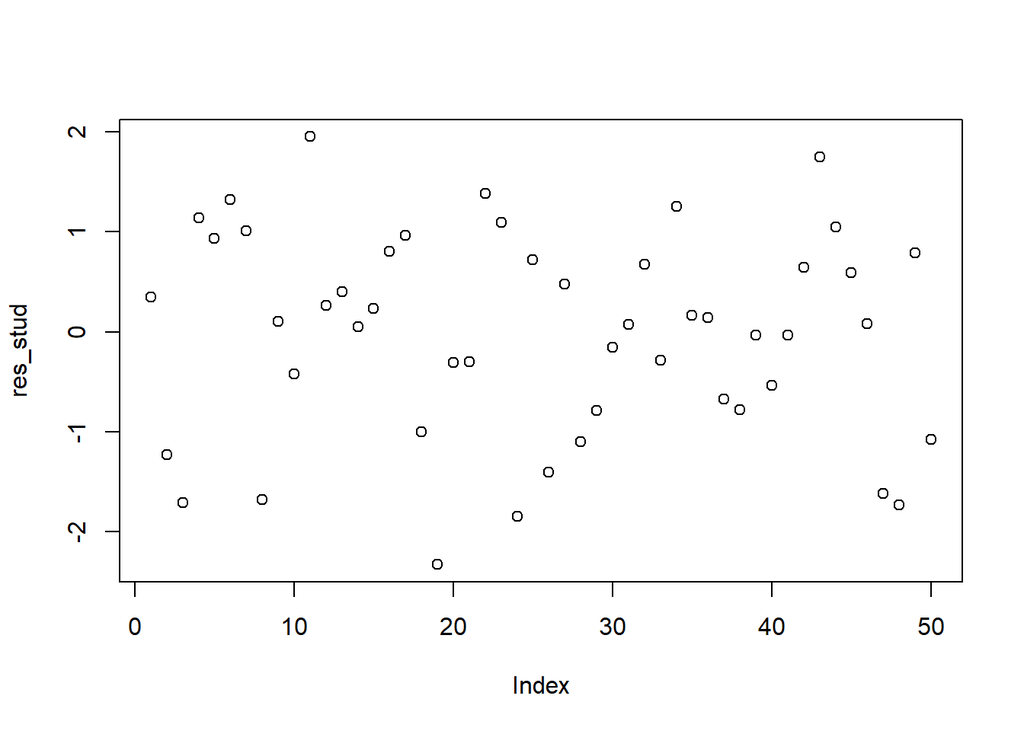

```r
suppressMessages(attach(reg3))
y.hat<-modelo$fitted.values
res_stud<-rstudent(modelo)
res_pad<-rstandard(modelo)
plot(res_stud)
```

#### Normalidade

**Código**

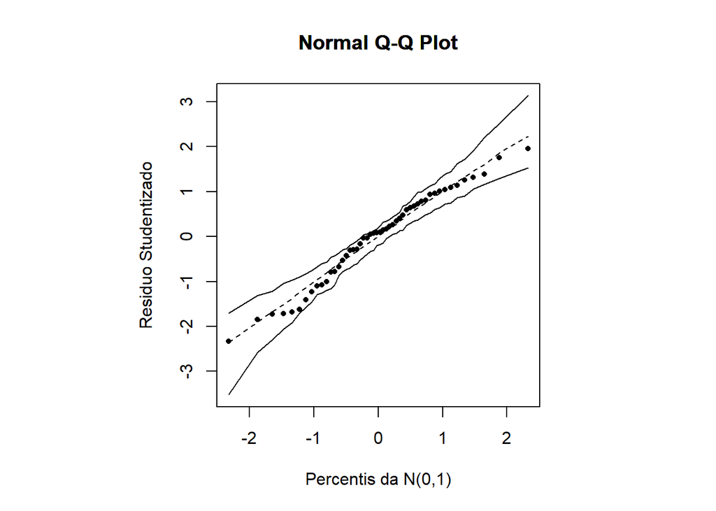

```r
envel_norm(modelo)
```

Os resíduos podem ser considerados normalmente distribuídos.

#### Homodedasticidade

**Código**

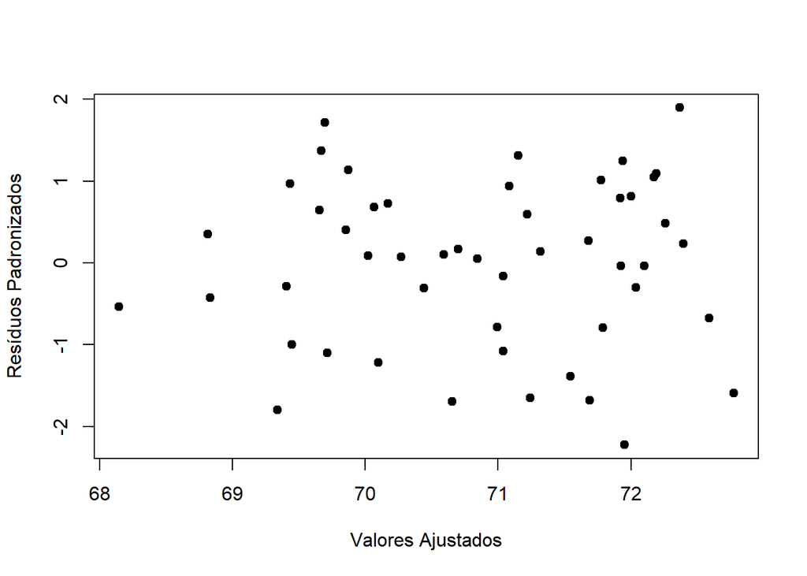

```r
plot(y.hat,res_pad,xlab="Valores Ajustados", ylab="Resíduos Padronizados",pch=19)
```

Não foi identificado padrões que indiquem que os erros são heterocedásticos.

#### Resíduo x variável explicativa

**Código**

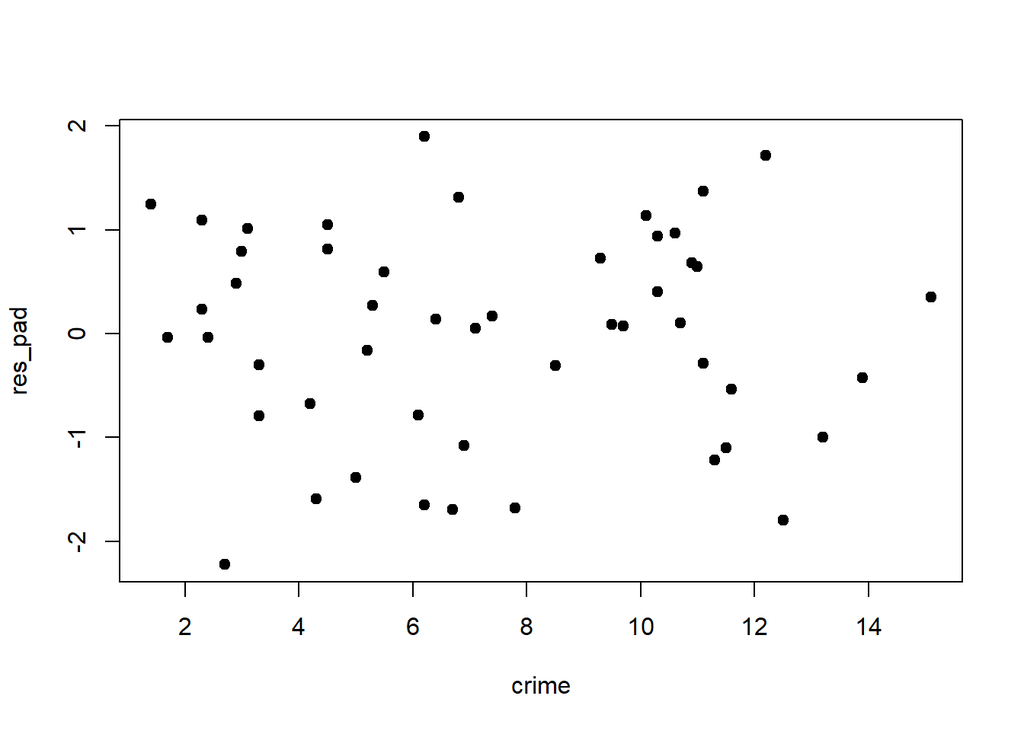

```r
plot(crime, res_pad, pch=19)
```

**Código**

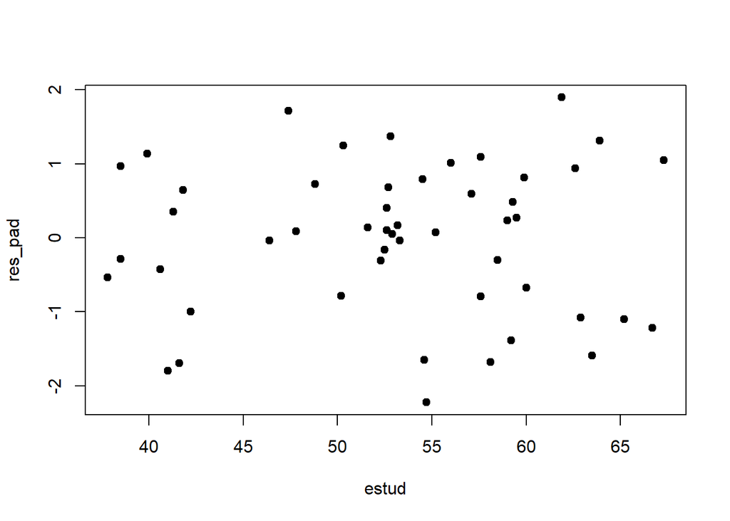

```r
plot(estud, res_pad, pch=19)
```

**Código**

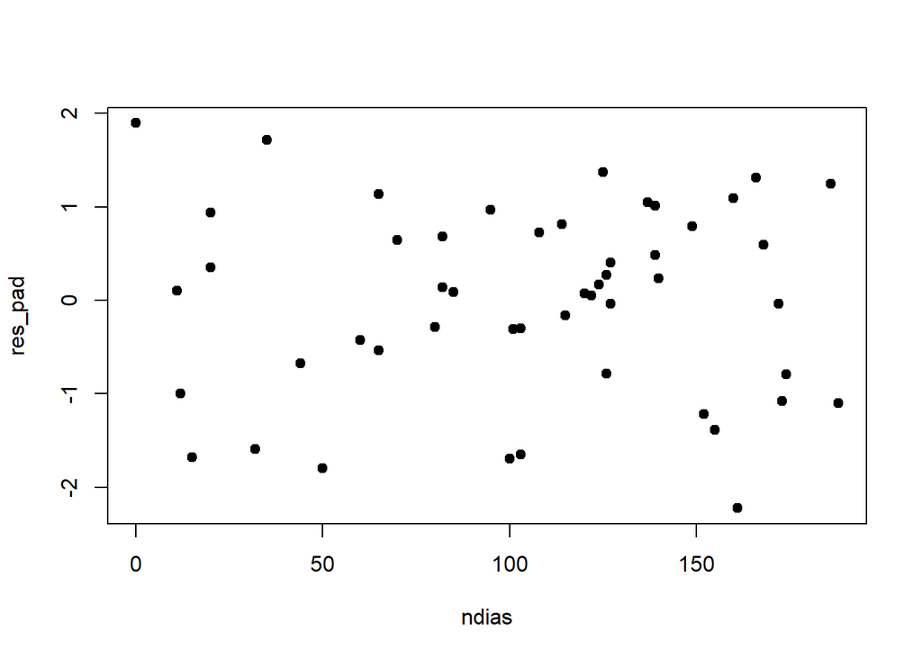

```r
plot(ndias, res_pad, pch=19)
```

**Código**

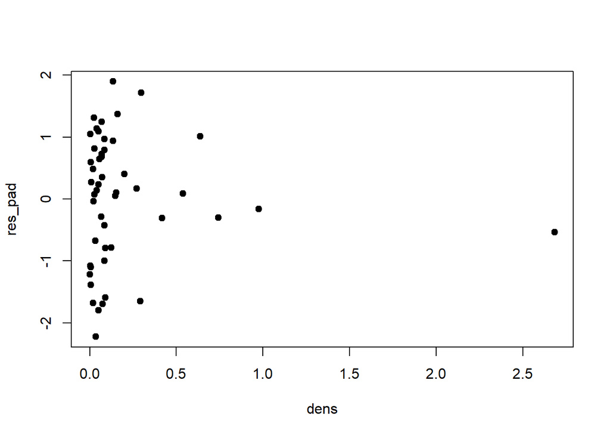

```r
plot(dens, res_pad, pch=19)
```

Não parece haver mais nenhuma contribuição das variáveis explicativas crime, estud, ndias e dens.

**Modelo validado!**

### Análise de diagnóstico

**Código**

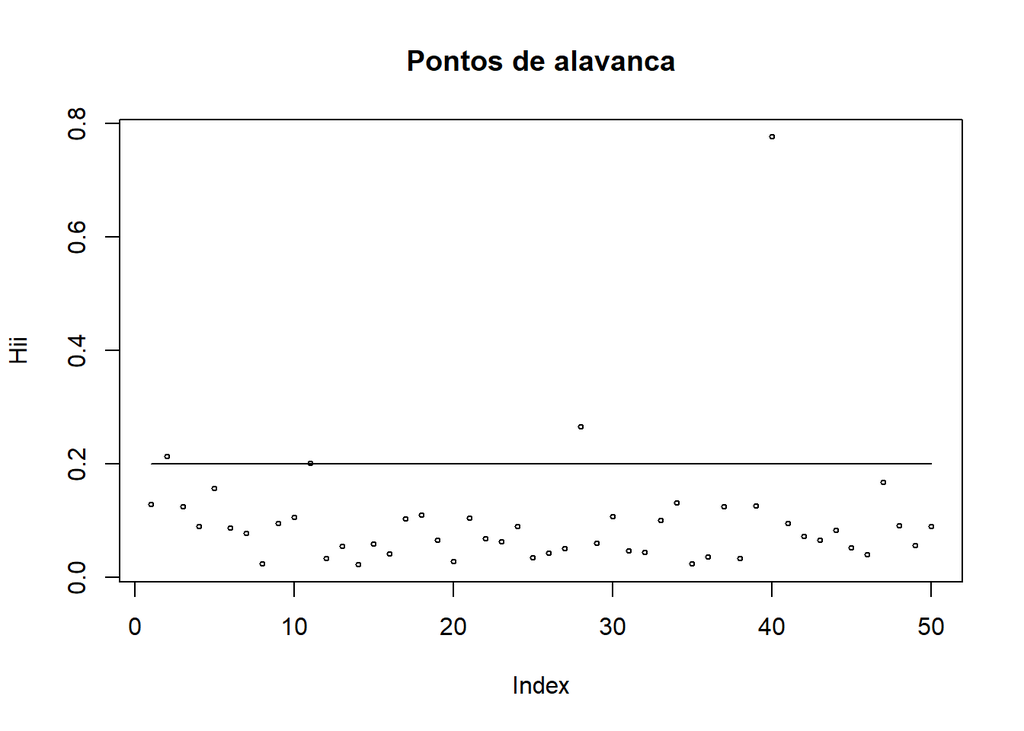

```r
# X<-matrix(c(rep(1,50), crime, estud, ndias, dens), ncol=5, nrow=50, byrow = F)
# H<-X%*%solve(t(X)%*%X)%*%t(X)
# QMRes <- sum(modelo$residuals^2)/45  # quadrado medio dos residuos
# sigma2 <- ((n-p)/n)*QMRes

influ<-influence.measures(modelo)
deffits=influ$infmat[,6] # conferir coluna
cook=influ$infmat[,8] # conferir coluna
Hii=influ$infmat[,9] # conferir coluna

n<-nrow(reg3)
p<-5


corte=2*p/n
plot(Hii, pch=1, main='Pontos de alavanca', cex=0.5)
lines(1:n,corte*rep(1,n))
```

**Código**

```r
#identify(Hii, n=2, tolerance = 2)
```

**Código**

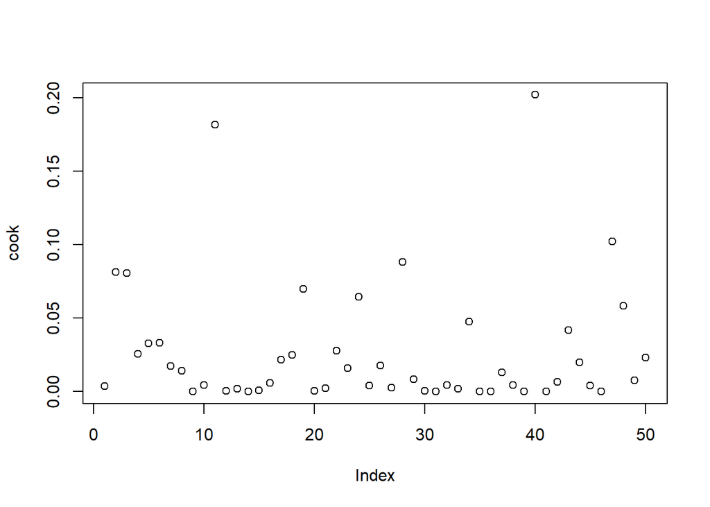

```r
corte=pf(0.5,p,n-p)
plot(cook)
lines(1:n,corte*rep(1,n), lty=2, col='maroon')
```

**Código**

```r
summary(influ)
```

```
Potentially influential observations of
     lm(formula = expvida ~ crime + estud + ndias + dens, data = reg3) :

   dfb.1_ dfb.crim dfb.estd dfb.ndis dfb.dens dffit cov.r   cook.d hat
40  0.05  -0.08     0.02    -0.06    -0.93    -1.00  4.86_*  0.20   0.78_*
```

A observação 40 referente ao estado South-Carolina é apontada como influente, ela parece impactar na matriz de covariâncias e foi apontada como alavanca.

### Interpretação

**Código**

```r
modelo
```

```
Call:
lm(formula = expvida ~ crime + estud + ndias + dens, data = reg3)

Coefficients:
(Intercept)        crime        estud        ndias         dens
  71.501488    -0.285873     0.043649    -0.007141    -0.456832
```

Temos que em um estado com uma taxa de criminalidade 0, com uma porcentagem de estudantes que concluíram o segundo grau de 0% e uma densidade populacional 2.684461 (máxima densidade do conjunto de dados) a expectativa de vida é aproximadamente 70 anos.

- Com o aumento de uma unidade na taxa de criminalidade a expectativa de vida diminui em média 0.29 anos.
- Com o aumento a porcentagem de estududantes a expectativa de vida aumenta em média 0.04 anos.
- Com o aumento de um unidade no número de dias com temperaturas abaixo de zero a expectativa de vida diminui em média 0.007 anos.
- Com o aumento de uma unidade na densidade populacional a expectativa de vida diminui em 0.45 anos.

## 20

- 1. telhados, total de telhados vendidos (em mil metros quadrados);
- 2. gastos, gastos pela loja com promoções do produto (em mil USD);
- 3. clientes, número de clientes cadastrados na loja (em milhares);
- 4. marcas, número de marcas concorrentes do produto;
- 22. potencial, potencial da loja (quanto maior o valor maior o potencial). Um dos objetivos do estudo com esse conjunto de dados é tentar prever o número esperado de telhados vendidos dadas as variáveis explicativas.

**Código**

```r
vendas<-read.table("./dados/lista1/vendas.txt", quote="\"")
colnames(vendas) <- c("telhados",
                    "gastos",
                    "clientes",
                    "marcas",
                    "potencial")
```

### Análise exploratória

**Código**

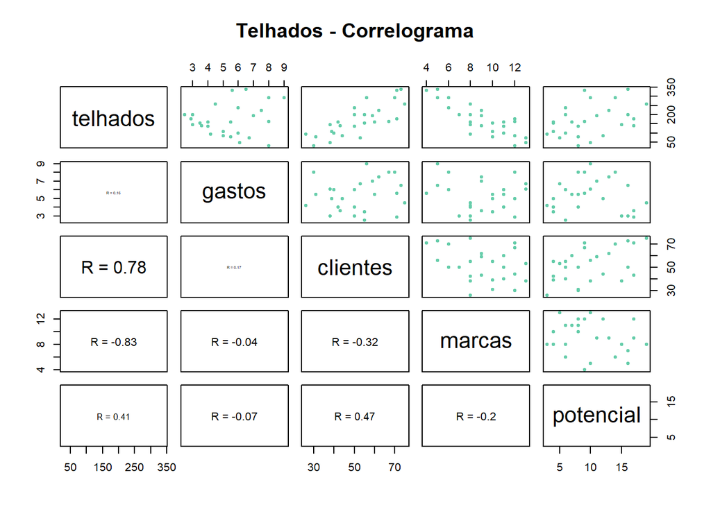

```r
attach(vendas)
pairs(vendas[,c(1:5)], main = "Telhados - Correlograma", pch = 20, col="aquamarine3",
    lower.panel = painel.prop)
```

No gráfico acima temos o diagrama de dispersão de todas as possíveis variáveis explicativas com a resposta. A que não parece ter um relacionamento linear forte com a venda de telhados é o gasto com promoções do produto.

**Código**

```r
ajuste0<-lm(telhados~gastos+marcas+potencial+clientes, data = vendas)
```

### Seleção de variáveis

Vamos utilizar o critério AIC para selecionar as variáveis.

**Código**

```r
ajuste<-stepAIC(ajuste0,direction="backward")
```

```
Start:  AIC=122.08
telhados ~ gastos + marcas + potencial + clientes

            Df Sum of Sq   RSS    AIC
- potencial  1        44  1982 120.67
<none>                    1937 122.08
- gastos     1       258  2195 123.33
- clientes   1     38269 40207 198.94
- marcas     1     66683 68620 212.83

Step:  AIC=120.67
telhados ~ gastos + marcas + clientes

           Df Sum of Sq   RSS    AIC
<none>                   1982 120.67
- gastos    1       229  2210 121.51
- clientes  1     49844 51825 203.54
- marcas    1     67104 69086 211.01
```

As variáveis selecionadas são: gastos, marcas e clientes

**Código**

```r
modelo<-lm(telhados ~ gastos + marcas + clientes)
summary(modelo)
```

```
Call:
lm(formula = telhados ~ gastos + marcas + clientes)

Residuals:
     Min       1Q   Median       3Q      Max
-20.4450  -4.6552   0.6802   6.1668  14.3571

Coefficients:
            Estimate Std. Error t value Pr(>|t|)
(Intercept) 179.8443    12.6213  14.249 1.37e-12 ***
gastos        1.6772     1.0521   1.594    0.125
marcas      -21.2165     0.7773 -27.295  < 2e-16 ***
clientes      3.3694     0.1432  23.524  < 2e-16 ***
---
Signif. codes:  0 '***' 0.001 '**' 0.01 '*' 0.05 '.' 0.1 ' ' 1

Residual standard error: 9.491 on 22 degrees of freedom
Multiple R-squared:  0.9889,    Adjusted R-squared:  0.9874
F-statistic: 654.1 on 3 and 22 DF,  p-value: < 2.2e-16
```

Mesmo gastos não sendo significativa ela deve estar no modelo, esse modelo foi o selecionado pelo critério AIC.

### Análise de resíduos

*MODELO:* telhados ~ gastos + marcas + clientes

**Código**

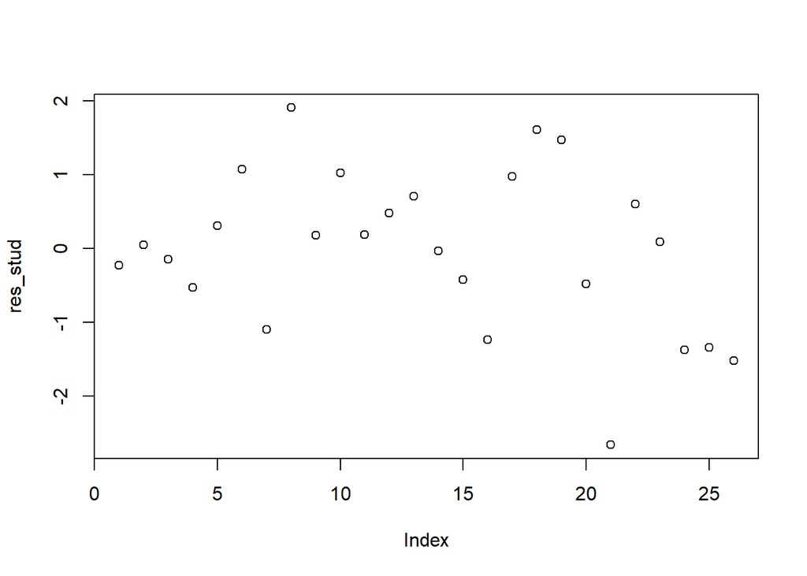

```r
suppressMessages(attach(vendas))
y.hat<-modelo$fitted.values
res_stud<-rstudent(modelo)
res_pad<-rstandard(modelo)
plot(res_stud)
```

#### Normalidade

**Código**

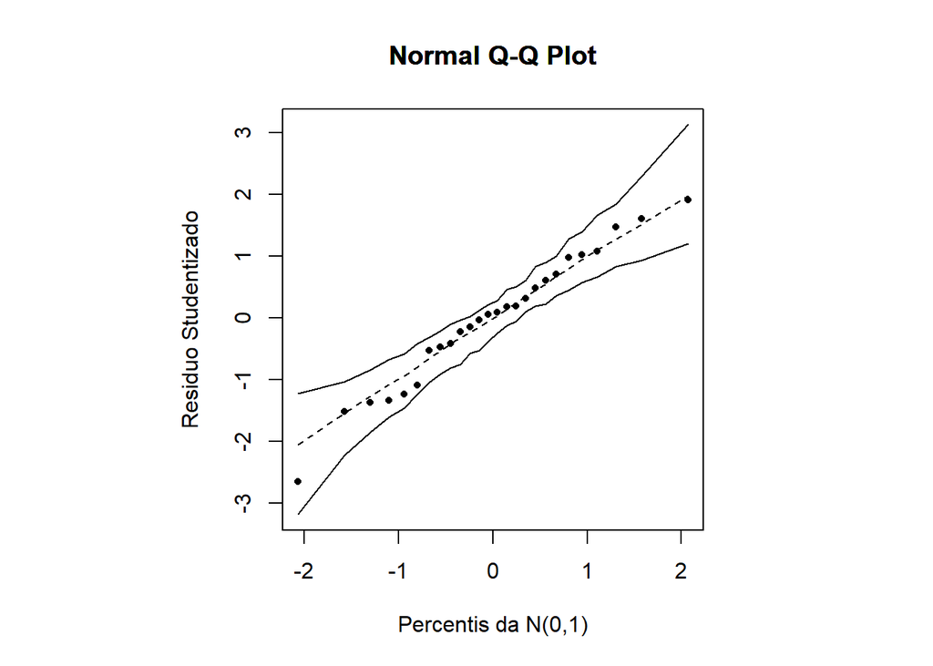

```r
envel_norm(modelo)
```

Os resíduos podem ser considerados normalmente distribuídos.

#### Homodedasticidade

**Código**

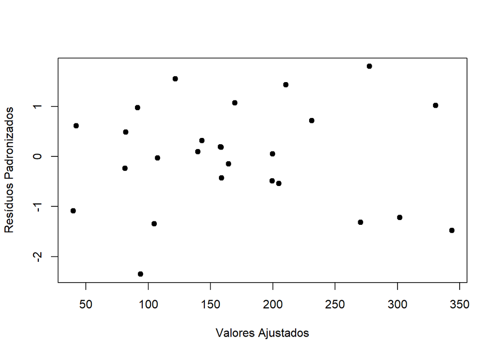

```r
plot(y.hat,res_pad,xlab="Valores Ajustados", ylab="Resíduos Padronizados",pch=19)
```

Não foi identificado padrões que indiquem que os erros são heterocedásticos.

#### Resíduo x variável explicativa

**Código**

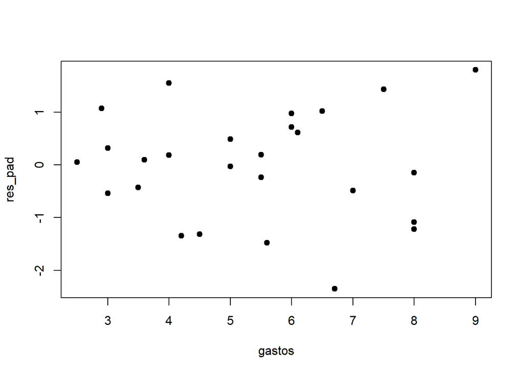

```r
plot(gastos, res_pad, pch=19)
```

**Código**

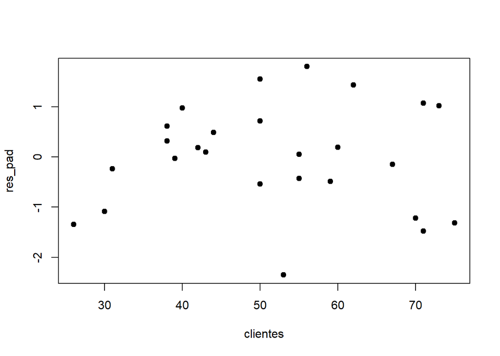

```r
plot(clientes, res_pad, pch=19)
```

**Código**

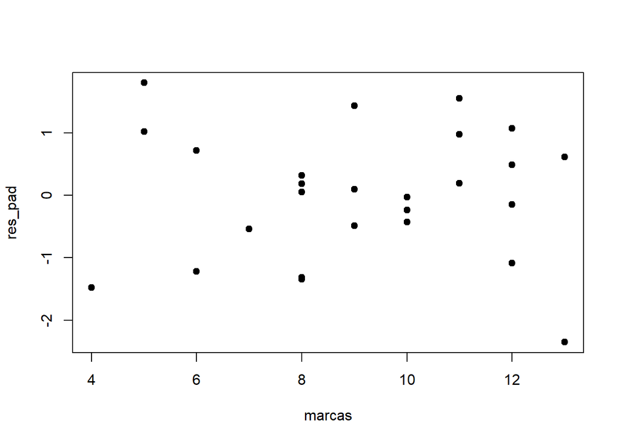

```r
plot(marcas, res_pad, pch=19)
```

Não parece haver mais nenhuma contribuição das variáveis explicativas gastos, clientes e marcas.

**Modelo validado!**

### Análise de diagnóstico

**Código**

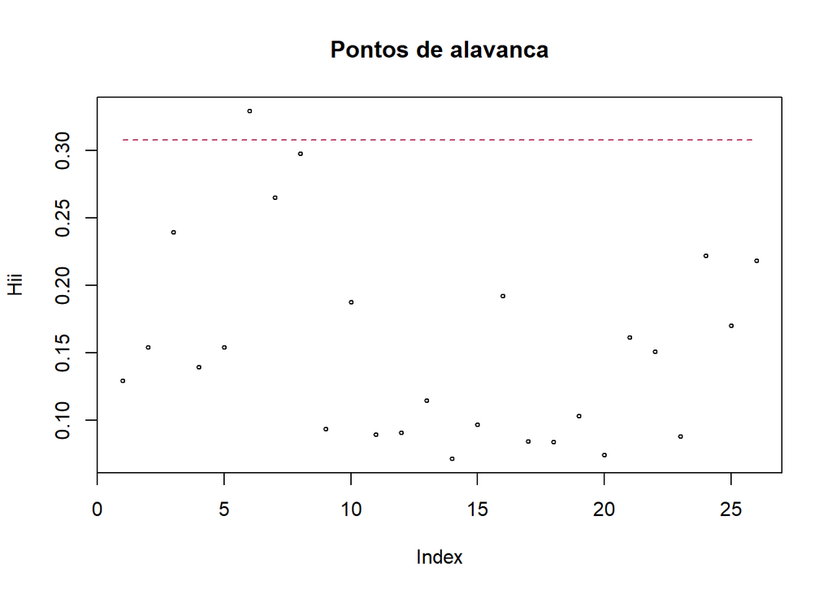

```r
influ<-influence.measures(modelo)
deffits=influ$infmat[,5] # conferir coluna
cook=influ$infmat[,7] # conferir coluna
Hii=influ$infmat[,8] # conferir coluna

n<-nrow(vendas)
p<-4


corte=2*p/n
plot(Hii, pch=1, main='Pontos de alavanca', cex=0.5)
lines(1:n,corte*rep(1,n),lty=2, col='maroon')
```

**Código**

```r
#identify(Hii, n=2, tolerance = 2)
```

A observação 6 parece ser ponto de alavanca.

**Código**

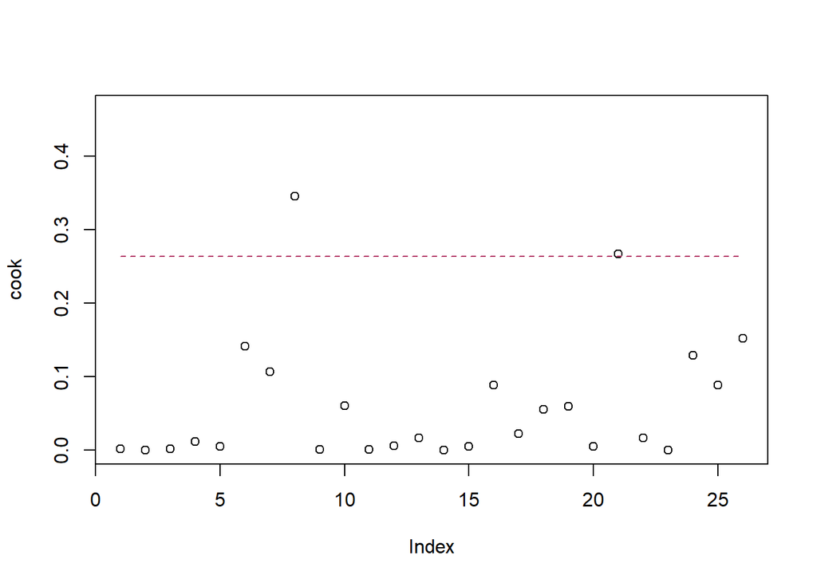

```r
corte=pf(0.5,p,n-p)
plot(cook, ylim = c(0,corte+0.2))
lines(1:n,corte*rep(1,n), lty=2, col='maroon')
```

**Código**

```r
# identify(cook, n=2, tolerance = 1.5)
```

As observações 8 e 21 parecem ser influentes.

**Código**

```r
summary(influ)
```

```
Potentially influential observations of
     lm(formula = telhados ~ gastos + marcas + clientes) :

   dfb.1_ dfb.gsts dfb.mrcs dfb.clnt dffit cov.r   cook.d hat
3   0.07  -0.04    -0.05    -0.04    -0.08  1.58_*  0.00   0.24
21  0.78  -0.39    -0.93    -0.28    -1.17  0.45_*  0.27   0.16
```

As observações 3 e 21 foram apontadas como influentes, elas parecem impactar na matriz de covariâncias.

### Interpretação

**Código**

```r
modelo
```

```
Call:
lm(formula = telhados ~ gastos + marcas + clientes)

Coefficients:
(Intercept)       gastos       marcas     clientes
    179.844        1.677      -21.217        3.369
```

- Com o aumento de uma unidade nos gastos com promoções do produto espera-se que as vendas aumentem em média 2 unidades aproximadamente.
- Com o aumento de uma unidade no número de marcas concorrentes do produto espera-se que em média as vendas caiam em aproximadamente 21 unidades.
- Com o aumento de um unidade no número de clientes cadastrados na loja espera-se que em média o número de vendas aumente em aproximadamente 3 unidades.

## 22

1. imposto do imóvel (em 100 USD);
2. área do terreno (em 1000 pés quadrados);
3. área construída (em 1000 pés quadrados);
4. idade da residência (em anos);
5. preço de venda do imóvel (em 1000 USD). Ajuste um modelo normal linear do preço de venda contra as demais variáveis.

**Código**

```r
imoveis<-read.table("./dados/lista1/imoveis.txt", quote="\"")
colnames(imoveis) <- c("imposto",
                    "area_terreno",
                    "area_const",
                    "idade",
                    "preco")
```

### Análise exploratória

**Código**

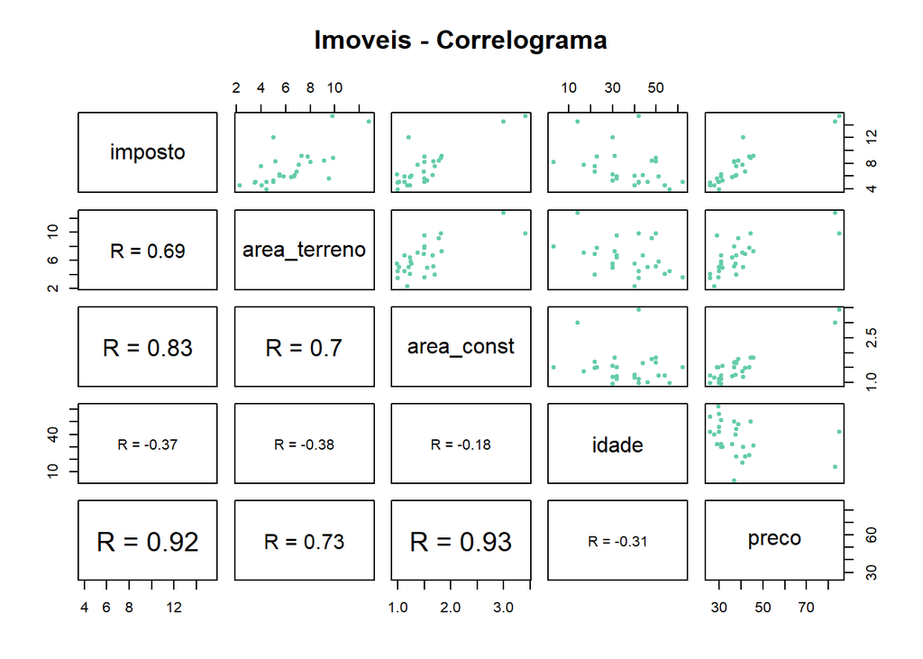

```r
attach(imoveis)
pairs(imoveis[,c(1:5)], main = "Imoveis - Correlograma", pch = 20, col="aquamarine3",
    lower.panel = painel.prop)
```

No gráfico acima temos o diagrama de dispersão de todas as possíveis variáveis explicativas com a resposta. As variáveis imposto, área do terreno e área construída possuem uma correlação bem alta com o preço de venda do imóvel. A idade do imóvel está correlacionada com o preço do imóvel de forma negativa.

**Código**

```r
ajuste0<-lm(preco~imposto+area_const+area_terreno+idade, data = imoveis)
```

### Seleção de variáveis

Vamos utilizar o critério AIC para selecionar as variáveis.

**Código**

```r
ajuste<-stepAIC(ajuste0,direction="backward")
```

```
Start:  AIC=80.36
preco ~ imposto + area_const + area_terreno + idade

               Df Sum of Sq    RSS    AIC
- area_terreno  1      3.50 369.14 78.614
- idade         1      7.25 372.88 78.887
<none>                      365.64 80.357
- imposto       1    234.76 600.40 91.748
- area_const    1    384.13 749.77 97.746

Step:  AIC=78.61
preco ~ imposto + area_const + idade

             Df Sum of Sq    RSS    AIC
- idade       1     11.51 380.64 77.443
<none>                    369.14 78.614
- imposto     1    246.10 615.24 90.407
- area_const  1    489.34 858.47 99.402

Step:  AIC=77.44
preco ~ imposto + area_const

             Df Sum of Sq    RSS    AIC
<none>                    380.64 77.443
- imposto     1    350.01 730.65 93.049
- area_const  1    483.16 863.80 97.569
```

As variáveis selecionadas são: imposto e área construída.

**Código**

```r
modelo<-lm(preco ~ imposto + area_const )
summary(modelo)
```

```
Call:
lm(formula = preco ~ imposto + area_const)

Residuals:
    Min      1Q  Median      3Q     Max
-6.0177 -3.3169  0.0958  2.4382  7.0949

Coefficients:
            Estimate Std. Error t value Pr(>|t|)
(Intercept)   0.7903     2.2794   0.347    0.732
imposto       2.2971     0.4890   4.698 8.96e-05 ***
area_const   13.9333     2.5244   5.519 1.12e-05 ***
---
Signif. codes:  0 '***' 0.001 '**' 0.01 '*' 0.05 '.' 0.1 ' ' 1

Residual standard error: 3.982 on 24 degrees of freedom
Multiple R-squared:  0.9285,    Adjusted R-squared:  0.9225
F-statistic: 155.8 on 2 and 24 DF,  p-value: 1.791e-14
```

### Análise de resíduos

*MODELO:* preco ~ imposto + area_const

**Código**

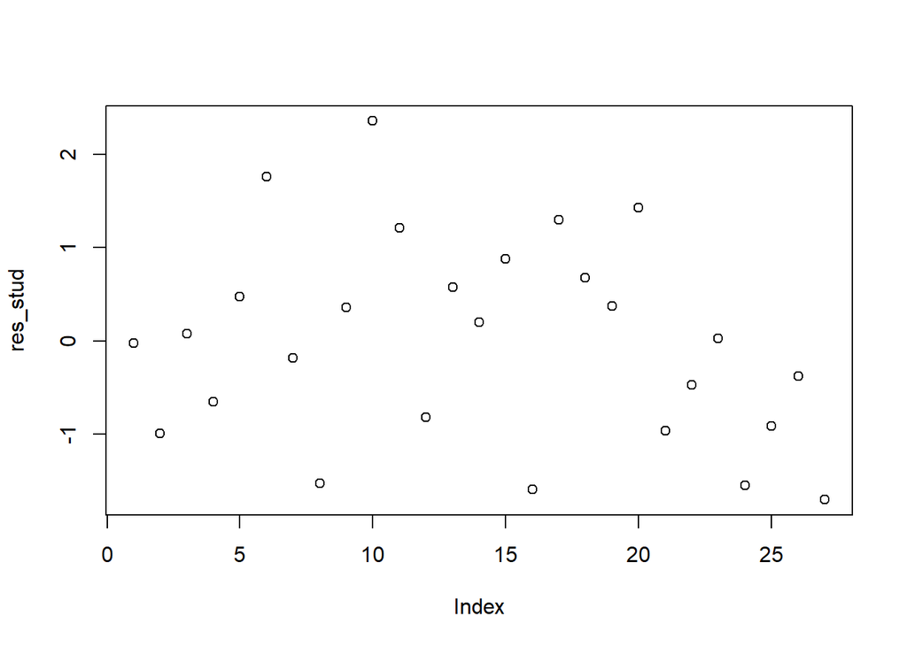

```r
suppressMessages(attach(imoveis))
y.hat<-modelo$fitted.values
res_stud<-rstudent(modelo)
res_pad<-rstandard(modelo)
plot(res_stud)
```

#### Normalidade

**Código**

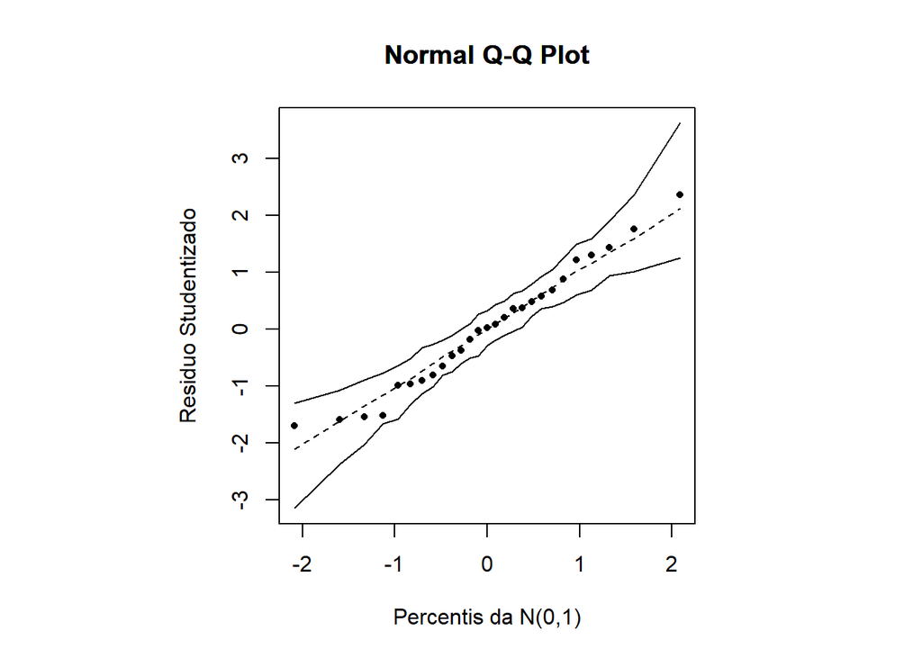

```r
envel_norm(modelo)
```

Os resíduos podem ser considerados normalmente distribuídos.

#### Homodedasticidade

**Código**

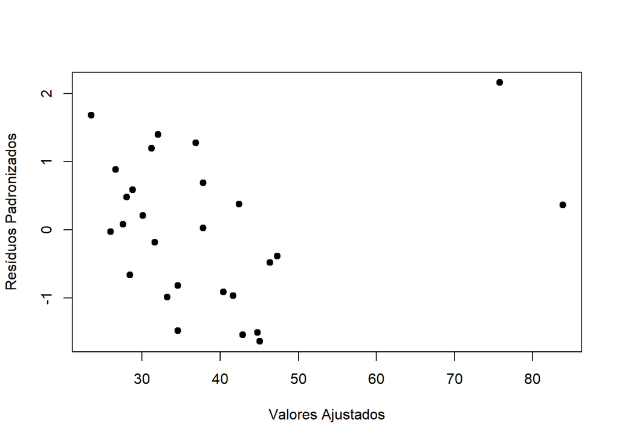

```r
plot(y.hat,res_pad,xlab="Valores Ajustados", ylab="Resíduos Padronizados",pch=19)
```

Não foi identificado padrões que indiquem que os erros são heterocedásticos.

#### Resíduo x variável explicativa

**Código**

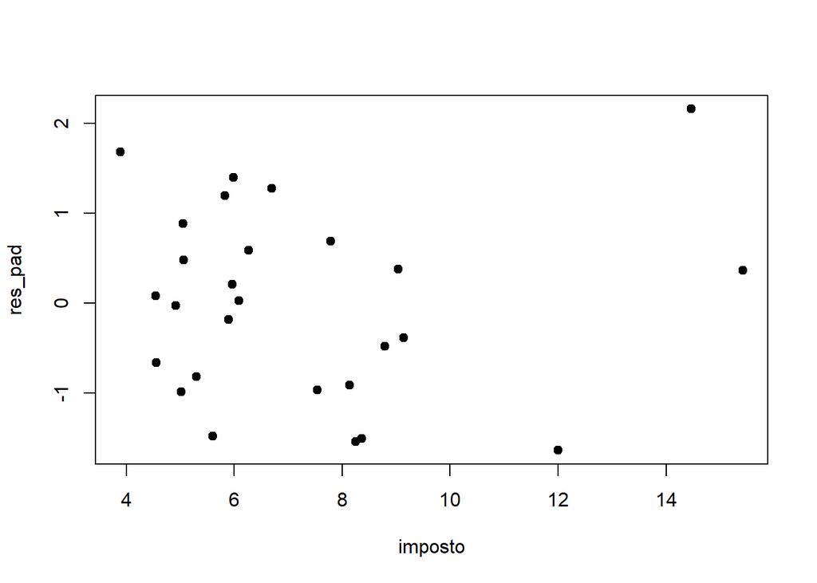

```r
plot(imposto, res_pad, pch=19)
```

**Código**

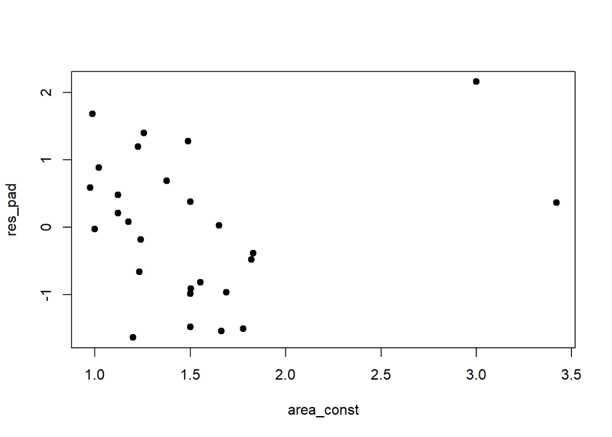

```r
plot(area_const, res_pad, pch=19)
```

Não parece haver mais nenhuma contribuição das variáveis explicativas.

**Modelo validado!**

### Análise de diagnóstico

**Código**

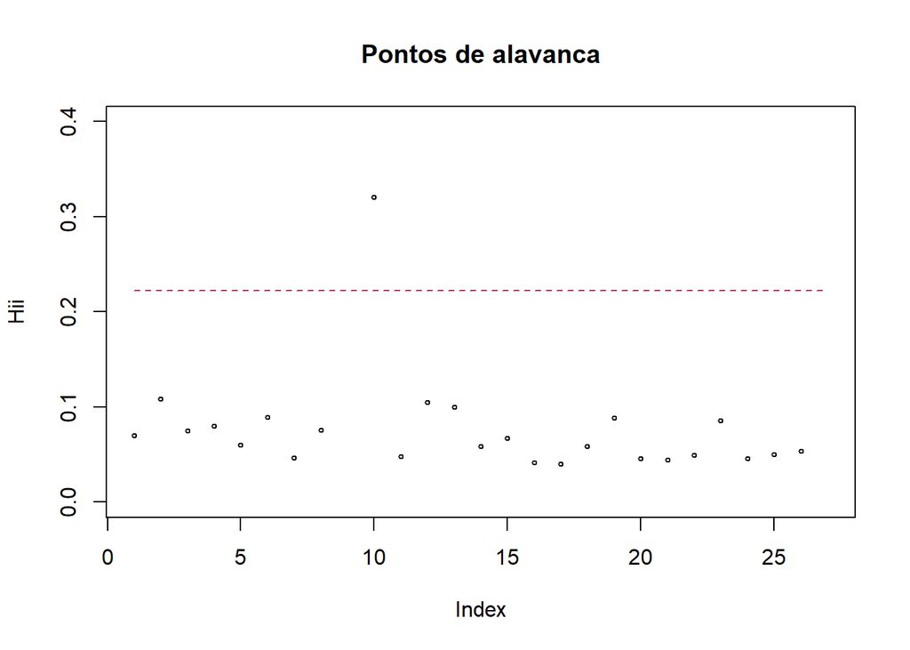

```r
influ<-influence.measures(modelo)
deffits=influ$infmat[,4] # conferir coluna
cook=influ$infmat[,6] # conferir coluna
Hii=influ$infmat[,7] # conferir coluna

n<-nrow(imoveis)
p<-3

corte=2*p/n
plot(Hii, pch=1, main='Pontos de alavanca', cex=0.5, ylim=c(0,0.4))
lines(1:n,corte*rep(1,n),lty=2, col='maroon')
```

**Código**

```r
#identify(Hii, n=2, tolerance = 2)
```

**Código**

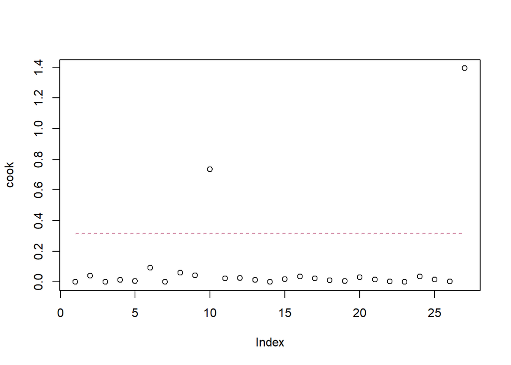

```r
corte=pf(0.5,p,n-p)
plot(cook)
lines(1:n,corte*rep(1,n), lty=2, col='maroon')
```

**Código**

```r
# identify(cook, n=2, tolerance = 1.5)
```

As observações 10 e 27 parecem ser influentes.

**Código**

```r
summary(influ)
```

```
Potentially influential observations of
     lm(formula = preco ~ imposto + area_const) :

   dfb.1_  dfb.imps dfb.ar_c dffit   cov.r   cook.d  hat
9  -0.28    0.00     0.19     0.35    2.18_*  0.04    0.49_*
10 -1.25_*  0.29     0.59     1.62_*  0.87    0.73    0.32
27 -0.13   -2.04_*   1.86_*  -2.12_*  2.04_*  1.39_*  0.61_*
```

As observações 9, 10 e 27 foram apontadas como influentes. A 27 é ponto de alavanca e influencia na matriz de covariâncias e na estimação dos betas.

### Interpretação

**Código**

```r
modelo
```

```
Call:
lm(formula = preco ~ imposto + area_const)

Coefficients:
(Intercept)      imposto   area_const
     0.7903       2.2971      13.9333
```

- Com o aumento de uma unidade no valor do imposto espera-se que o preco de venda aumente em média 2 (1000 USD) aproximadamente.
- Com o aumento de uma unidade na área construída espera-se que em média o preco do imovel aumente em aproximadamente 14 mil dólares americanos.

## 23

No arquivo trees.dat é apresentado um conjunto de dados que tem sido analisado sob diversos pontos de vista por vários pesquisadores (ver, por exemplo, Jørgensen, 1989). As variáveis observadas são o diâmetro (d), a altura (h) e o volume (v) de uma amostra de 31 cerejeiras numa floresta do estado da Pensilvânia, EUA.

**Código**

```r
trees<-read.table("./dados/lista1/trees.txt", quote="\"")
colnames(trees) <- c("d",
                    "h",
                    "v")
```

**Código**

```r
trees<-trees |>
  mutate(ld=log(d),lh=log(h),lv=log(v))
```

**Código**

```r
suppressMessages(attach(trees))
modelo<-lm(lv~ld+lh)
summary(modelo)
```

```
Call:
lm(formula = lv ~ ld + lh)

Residuals:
      Min        1Q    Median        3Q       Max
-0.168561 -0.048488  0.002431  0.063637  0.129223

Coefficients:
            Estimate Std. Error t value Pr(>|t|)
(Intercept) -6.63162    0.79979  -8.292 5.06e-09 ***
ld           1.98265    0.07501  26.432  < 2e-16 ***
lh           1.11712    0.20444   5.464 7.81e-06 ***
---
Signif. codes:  0 '***' 0.001 '**' 0.01 '*' 0.05 '.' 0.1 ' ' 1

Residual standard error: 0.08139 on 28 degrees of freedom
Multiple R-squared:  0.9777,    Adjusted R-squared:  0.9761
F-statistic: 613.2 on 2 and 28 DF,  p-value: < 2.2e-16
```

### Análise de resíduos

*MODELO:* log(v) ~ a + blog(d)+clog(h)

**Código**

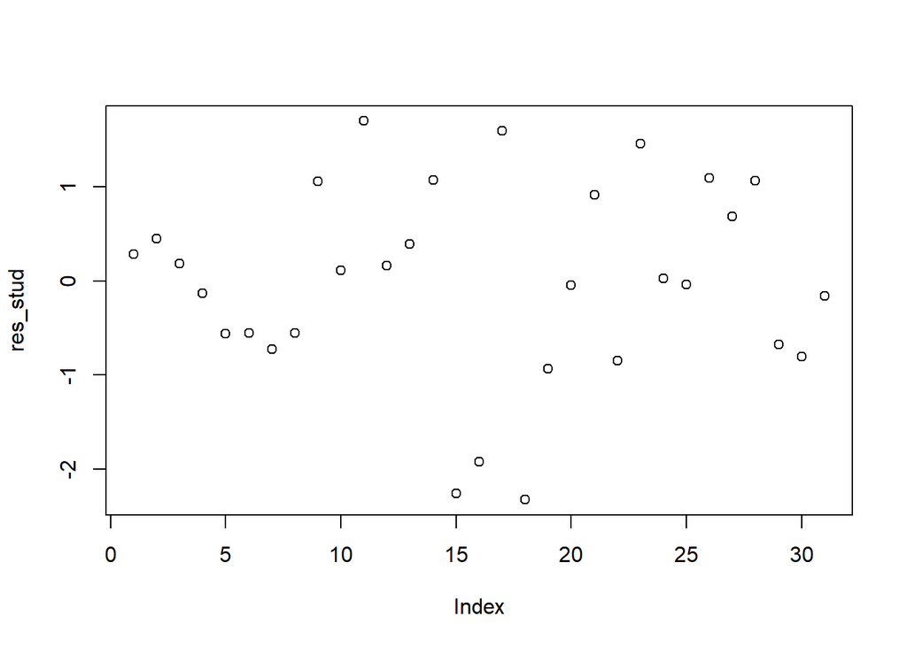

```r
y.hat<-modelo$fitted.values
res_stud<-rstudent(modelo)
res_pad<-rstandard(modelo)
plot(res_stud)
```

#### Normalidade

**Código**

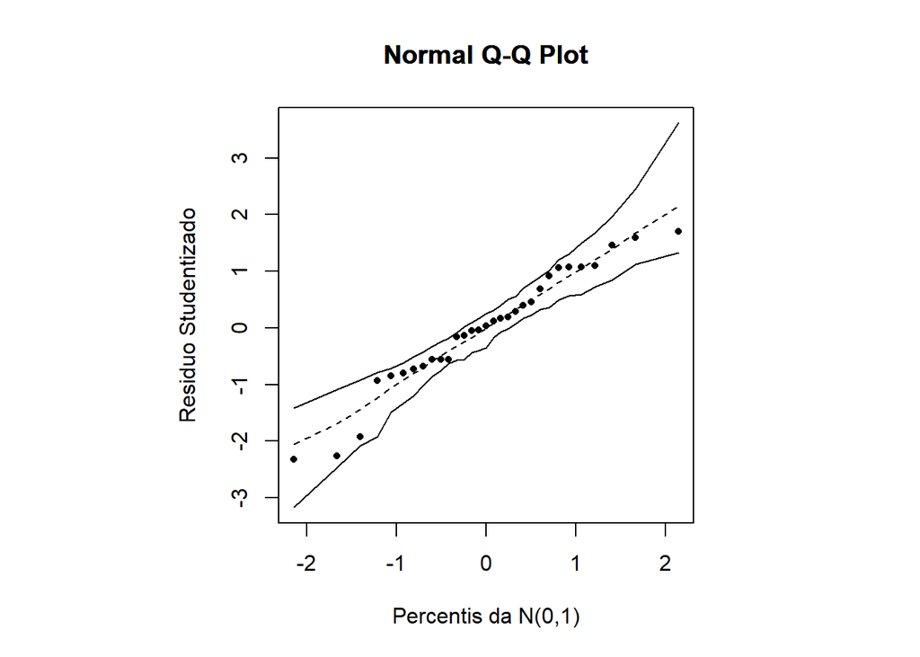

```r
envel_norm(modelo)
```

Os resíduos podem ser considerados normalmente distribuídos.

#### Homodedasticidade

**Código**

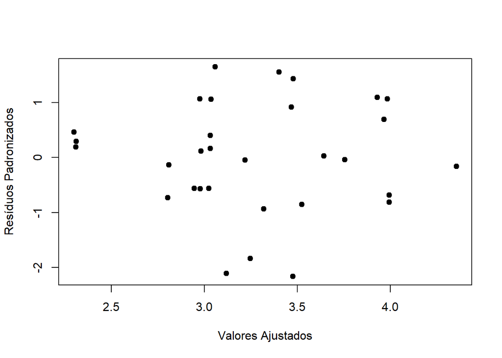

```r
plot(y.hat,res_pad,xlab="Valores Ajustados", ylab="Resíduos Padronizados",pch=19)
```

Não foi identificado padrões que indiquem que os erros são heterocedásticos.

#### Resíduo x variável explicativa

**Código**

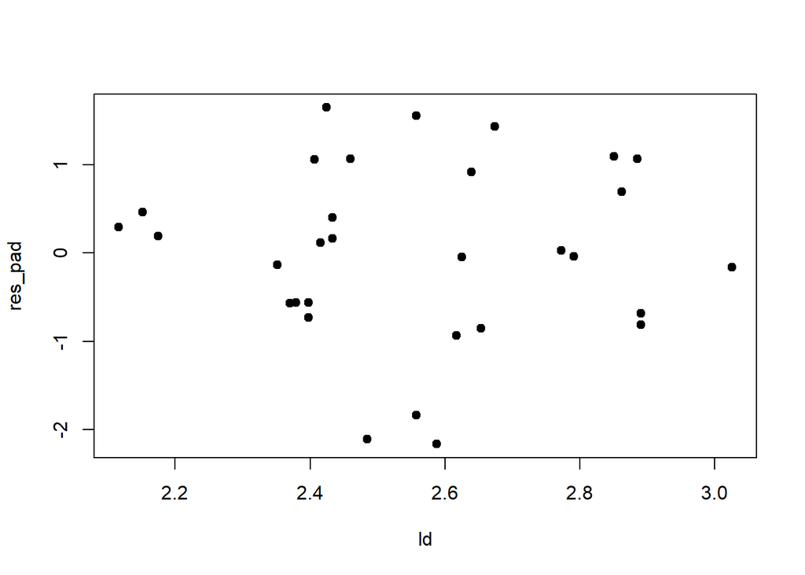

```r
plot(ld, res_pad, pch=19)
```

**Código**

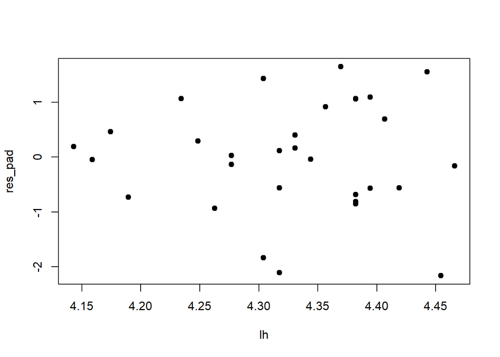

```r
plot(lh, res_pad, pch=19)
```

Não parece que o modelo possa ser melhorado ao incluir mais termos das variáveis explicativas.

**Modelo validado!**